# 05_5_Train_Test

# References

NOTE: the following material not fully original, but rather an extension of reference 1 with comments and other sources to improve the student’s understanding:

1. Hyndman, R. J., & Athanasopoulos, G. (2021). *Forecasting: principles and practice* (3rd ed.). [Link](https://otexts.com/fpp3/)
2. tidyverts.org. (n.d.). *fable package documentation*. Retrieved from:
- [Link 1](https://fable.tidyverts.org/index.html)
- [Link 2](https://fable.tidyverts.org/articles/fable.html)
3. Fischer, J. (n.d.). Was dem MAPE fälschlicherweise vorgeworfen wird: seine wahren Schwächen und bessere Alternativen. *STATWORX*. Retrieved from [Link](https://www.statworx.com/content-hub/blog/was-dem-mape-falschlicherweise-vorgeworfen-wird-seine-wahren-schwachen-und-bessere-alternativen/)
4. Hyndman, R. J., & Koehler, A. B. (2006). Another look at measures of forecast accuracy. *International Journal of Forecasting, 22*(4), 679–688.

# Packages

```r
library(fpp3)
```

# Train and Test Sets

The size of the residuals is not a reliable indication of how large true forecast errors are likely to be. **The accuracy of forecasts can only be determined by considering how well a model performs on new data that were not used when fitting the model.**

However, **the problem is that we do not have data on which to test the forecasts, since these are into the future.**

**Common Practice**: separate available data in two portions - **train** and **test**

- **train data**: used to fit the model (to estimate the model parameters)
- **test data**: used to evaluate model accuracy.

This is shown in the graphs below:

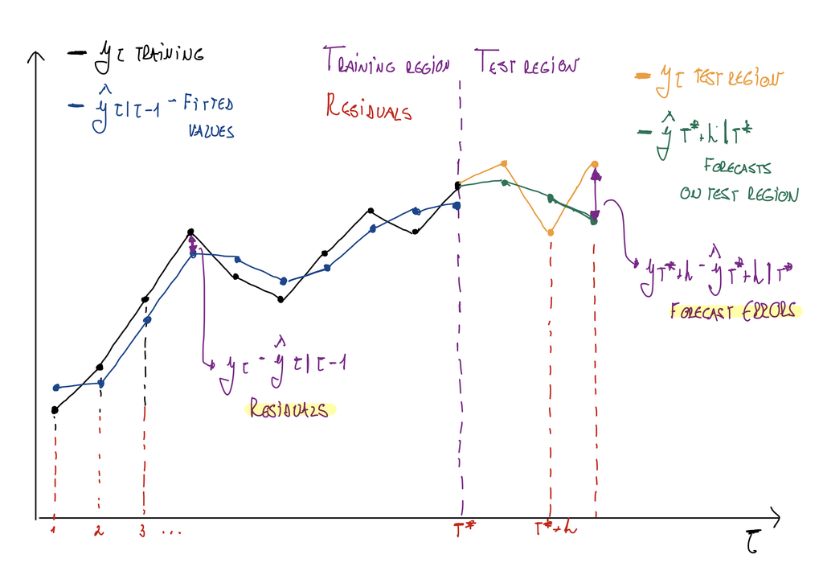

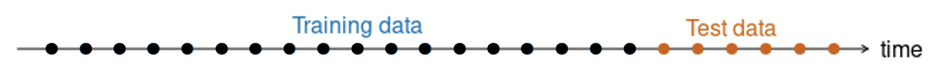

**Indicatons to choose test data size**

- Typically **around 20% of the total sample**
- **At least as large as the maximum forecast horizon required**
- **Ideally much longer as the forecast horizon required (3 times min)**

**Important considerations**

- A **model that fits the training data well will not necessarily forecast well.**
- A perfect fit to the training data can always be obtained with enough parameters (**over-fitting**)
  - Over-fitting a model to data is just as bad as not identifying a pattern in the data.

## Functions to subset a time series

### `filter()`

`filter()` can be used to filter out a portion of a time series.

- It is **important to convert your time index to something that can be compared against the object you want to filter by**. In the example below we need to convert the `yearquarter` index to a `year` before comparing against 1995.

```r
# Data from 1995 onwards
aus_production %>% filter(year(Quarter) >= 1995)
```

```
# A tsibble: 62 x 7 [1Q]
   Quarter  Beer Tobacco Bricks Cement Electricity   Gas
     <qtr> <dbl>   <dbl>  <dbl>  <dbl>       <dbl> <dbl>
 1 1995 Q1   426    4714    430   1626       41768   131
 2 1995 Q2   408    3939    457   1703       43686   167
 3 1995 Q3   416    6137    417   1733       46022   181
 4 1995 Q4   520    4739    370   1545       42800   145
 5 1996 Q1   409    4275    310   1526       43661   133
 6 1996 Q2   398    5239    358   1593       44707   162
 7 1996 Q3   398    6293    379   1706       46326   184
 8 1996 Q4   507    5575    369   1699       43346   146
 9 1997 Q1   432    4802    330   1511       43938   135
10 1997 Q2   398    5523    390   1785       45828   171
# ℹ 52 more rows
```

More examples on the use of filter in the exercises below, that will be provided with solutions in due course.

### `slice()`

`slice()`: allows extraction by indices.

```r
# Extact the first 12 points (1 year) of data of each combination of State, Industry
aus_retail %>%
  group_by(State, Industry)  %>%
  slice(1:12) %>%
  ungroup() # So that subsequent operations are not performed group-wise
```

```
# A tsibble: 1,824 x 5 [1M]
# Key:       State, Industry [152]
   State                        Industry           `Series ID`    Month Turnover
   <chr>                        <chr>              <chr>          <mth>    <dbl>
 1 Australian Capital Territory Cafes, restaurant… A3349849A   1982 Apr      4.4
 2 Australian Capital Territory Cafes, restaurant… A3349849A   1982 May      3.4
 3 Australian Capital Territory Cafes, restaurant… A3349849A   1982 Jun      3.6
 4 Australian Capital Territory Cafes, restaurant… A3349849A   1982 Jul      4
 5 Australian Capital Territory Cafes, restaurant… A3349849A   1982 Aug      3.6
 6 Australian Capital Territory Cafes, restaurant… A3349849A   1982 Sep      4.2
 7 Australian Capital Territory Cafes, restaurant… A3349849A   1982 Oct      4.8
 8 Australian Capital Territory Cafes, restaurant… A3349849A   1982 Nov      5.4
 9 Australian Capital Territory Cafes, restaurant… A3349849A   1982 Dec      6.9
10 Australian Capital Territory Cafes, restaurant… A3349849A   1983 Jan      3.8
# ℹ 1,814 more rows
```

Slice can be used in combination with **`n()` to refer to the maximum number of rows.**

- In the following examples **the parenthesis play a major role because the `:` operator takes precedence over the `-` operator, so in order to adequately reference the indexes we need to use the parenthesis**

#### Slice example 1

```r
# Extract everything put the last 12 observations of each series
# (each combination of State, Industry)
aus_retail %>%
  group_by(State, Industry) %>%
  slice(1:(n()-12)) %>%  # We need to enclose (n()-12) with parenthesis.
  ungroup() # So that subsequent operations are not performed group-wise
```

```
# A tsibble: 62,708 x 5 [1M]
# Key:       State, Industry [152]
   State                        Industry           `Series ID`    Month Turnover
   <chr>                        <chr>              <chr>          <mth>    <dbl>
 1 Australian Capital Territory Cafes, restaurant… A3349849A   1982 Apr      4.4
 2 Australian Capital Territory Cafes, restaurant… A3349849A   1982 May      3.4
 3 Australian Capital Territory Cafes, restaurant… A3349849A   1982 Jun      3.6
 4 Australian Capital Territory Cafes, restaurant… A3349849A   1982 Jul      4
 5 Australian Capital Territory Cafes, restaurant… A3349849A   1982 Aug      3.6
 6 Australian Capital Territory Cafes, restaurant… A3349849A   1982 Sep      4.2
 7 Australian Capital Territory Cafes, restaurant… A3349849A   1982 Oct      4.8
 8 Australian Capital Territory Cafes, restaurant… A3349849A   1982 Nov      5.4
 9 Australian Capital Territory Cafes, restaurant… A3349849A   1982 Dec      6.9
10 Australian Capital Territory Cafes, restaurant… A3349849A   1983 Jan      3.8
# ℹ 62,698 more rows
```

#### Slice example 2

The **`-` sign below** indicates that we are interested in **precisely what is not covered by (1:(n()-12))**.

```r
# Extract just last 12 observations of each series
# (each combination of State, Industry)
# Recall thath the - operator can be used here to indecate "everything but".
aus_retail %>%
  group_by(State, Industry) %>%
  slice(-(1:(n()-12))) %>% # We need to enclose (n()-12) with parenthesis.
  ungroup() # So that subsequent operations are not performed group-wise
```

```
# A tsibble: 1,824 x 5 [1M]
# Key:       State, Industry [152]
   State                        Industry           `Series ID`    Month Turnover
   <chr>                        <chr>              <chr>          <mth>    <dbl>
 1 Australian Capital Territory Cafes, restaurant… A3349849A   2018 Jan     33.8
 2 Australian Capital Territory Cafes, restaurant… A3349849A   2018 Feb     37.2
 3 Australian Capital Territory Cafes, restaurant… A3349849A   2018 Mar     44.3
 4 Australian Capital Territory Cafes, restaurant… A3349849A   2018 Apr     40.6
 5 Australian Capital Territory Cafes, restaurant… A3349849A   2018 May     40.9
 6 Australian Capital Territory Cafes, restaurant… A3349849A   2018 Jun     40.7
 7 Australian Capital Territory Cafes, restaurant… A3349849A   2018 Jul     43.8
 8 Australian Capital Territory Cafes, restaurant… A3349849A   2018 Aug     41.7
 9 Australian Capital Territory Cafes, restaurant… A3349849A   2018 Sep     41.4
10 Australian Capital Territory Cafes, restaurant… A3349849A   2018 Oct     41.7
# ℹ 1,814 more rows
```

#### Slice example 3

```r
# ALTERNATIVE: Extract just last 12 observations of each series
# (each combination of State, Industry)
aus_retail %>%
  group_by(State, Industry) %>%
  slice((n()-11):n()) %>% # We need to enclose (n()-11) with parenthesis.
  ungroup()
```

```
# A tsibble: 1,824 x 5 [1M]
# Key:       State, Industry [152]
   State                        Industry           `Series ID`    Month Turnover
   <chr>                        <chr>              <chr>          <mth>    <dbl>
 1 Australian Capital Territory Cafes, restaurant… A3349849A   2018 Jan     33.8
 2 Australian Capital Territory Cafes, restaurant… A3349849A   2018 Feb     37.2
 3 Australian Capital Territory Cafes, restaurant… A3349849A   2018 Mar     44.3
 4 Australian Capital Territory Cafes, restaurant… A3349849A   2018 Apr     40.6
 5 Australian Capital Territory Cafes, restaurant… A3349849A   2018 May     40.9
 6 Australian Capital Territory Cafes, restaurant… A3349849A   2018 Jun     40.7
 7 Australian Capital Territory Cafes, restaurant… A3349849A   2018 Jul     43.8
 8 Australian Capital Territory Cafes, restaurant… A3349849A   2018 Aug     41.7
 9 Australian Capital Territory Cafes, restaurant… A3349849A   2018 Sep     41.4
10 Australian Capital Territory Cafes, restaurant… A3349849A   2018 Oct     41.7
# ℹ 1,814 more rows
```

#### Slice example 4

The next one is a bit tricky and involves the operation precedence issue. First look at the following decreasing sequence that starts from 19 and ends at 0, in steps of 1.

```r
19:0
```

```
 [1] 19 18 17 16 15 14 13 12 11 10  9  8  7  6  5  4  3  2  1  0
```

Adding or subtracting an integer to that sequence does not alter the number of elements, rather, it only shifts the sequence accordingly

```r
200 - 19:0
```

```
 [1] 181 182 183 184 185 186 187 188 189 190 191 192 193 194 195 196 197 198 199
[20] 200
```

Using this, we can use the integer returned by `n()` when used within `dplyr` verbs (the number of rows) to obtain only the last 20 observations in the dataset:

```r
# Extract the latest 20 observations (20 quarters -> 5 years)
aus_production %>%
  slice(n()-19:0) # n()-19:0 is equivalent to 218-19:0 (218 is the number of
```

```
# A tsibble: 20 x 7 [1Q]
   Quarter  Beer Tobacco Bricks Cement Electricity   Gas
     <qtr> <dbl>   <dbl>  <dbl>  <dbl>       <dbl> <dbl>
 1 2005 Q3   408      NA     NA   2340       56043   221
 2 2005 Q4   482      NA     NA   2265       54992   180
 3 2006 Q1   438      NA     NA   2027       57112   171
 4 2006 Q2   386      NA     NA   2278       57157   224
 5 2006 Q3   405      NA     NA   2427       58400   233
 6 2006 Q4   491      NA     NA   2451       56249   192
 7 2007 Q1   427      NA     NA   2140       56244   187
 8 2007 Q2   383      NA     NA   2362       55036   234
 9 2007 Q3   394      NA     NA   2536       59806   245
10 2007 Q4   473      NA     NA   2562       56411   205
11 2008 Q1   420      NA     NA   2183       59118   194
12 2008 Q2   390      NA     NA   2558       56660   229
13 2008 Q3   410      NA     NA   2612       64067   249
14 2008 Q4   488      NA     NA   2373       59045   203
15 2009 Q1   415      NA     NA   1963       58368   196
16 2009 Q2   398      NA     NA   2160       57471   238
17 2009 Q3   419      NA     NA   2325       58394   252
18 2009 Q4   488      NA     NA   2273       57336   210
19 2010 Q1   414      NA     NA   1904       58309   205
20 2010 Q2   374      NA     NA   2401       58041   236
```

```r
                  # rows in aus_production).
```

## Exercises train-test datasets

1. Create a training and a test set for household wealth (dataset `hh_budget`) by withholding the last four years as a test set. Use `filter()` and a logical condition
2. Consider the dataset `global_economy` and in particular the data related to `Argentina`
- 2.1: Determine how many datapoints related to Argentina there are in the dataset (how many rows) and store that number in a variable. Also extract the series corresponding to Argentinian exports. Hint: you can use the function `nrow()` (in an exam context, no hint will be given).
- 2.2: Create a training dataset that consists on 80% of the observations. Since 80% of the observations is not an integer number, round it down to the nearest integer. The rest of the observations are to be stored as test dataset.
3. Create a training set for Australian takeaway food turnover (aus_retail) by withholding the last four years as a test set.
- 3.1: using filter() extract values corresponding to the industry “Takeaway food services”
- 3.2: Using `sum()` and `summarize()` obtain the aggregates turnover of this industry per month over all the states
- 3.3: Create your training and test datasets